```python
# This Python 3 environment comes with many helpful analytics libraries installed
# It is defined by the kaggle/python Docker image: https://github.com/kaggle/docker-python
# For example, here's several helpful packages to load

import numpy as np # linear algebra
import pandas as pd # data processing, CSV file I/O (e.g. pd.read_csv)

# Input data files are available in the read-only "../input/" directory
# For example, running this (by clicking run or pressing Shift+Enter) will list all files under the input directory

import os
#for dirname, _, filenames in os.walk('/kaggle/input'):
#    for filename in filenames:
#        print(os.path.join(dirname, filename))

# You can write up to 20GB to the current directory (/kaggle/working/) that gets preserved as output when you create a version using "Save & Run All"
# You can also write temporary files to /kaggle/temp/, but they won't be saved outside of the current session
```

```python
import cv2 # for working with images
import matplotlib.pyplot as plt # for visualizations
import matplotlib.patches as patches # for drawing on visualizations
import random # for generating random numbers
import time # for cell runtimes

from sklearn.model_selection import train_test_split # for splitting training into train and validation sets
from sklearn.metrics import roc_curve, auc, roc_auc_score, confusion_matrix # for model evaulation
from sklearn.metrics import ConfusionMatrixDisplay

# for building CNN model
from tensorflow import keras
from tensorflow.keras.models import Sequential
from tensorflow.keras.layers import Conv2D, BatchNormalization, MaxPooling2D, Dropout, Dense, Flatten
from keras.callbacks import EarlyStopping, ReduceLROnPlateau

# for pulling test images
import os
from glob import glob
```

[output not shown]

# Project Background

In this project I'll be training a model to identify the presence of cancer cells in histopathologic images. These images are sampled from the [PatchCamelyon dataset](https://github.com/basveeling/pcam) which is a large collection of histopathologic scans from lymph node sections. Identifying cancer cells in these images would be evidence that a patient's cancer has spread to the lymph nodes.

### Data Problem

This is a supervised classification problem with 2 class labels: 0 (no signs of cancer cells), and 1 (presence of cancer cells). The model of choice to work this problem is a convolutional neural network (CNN) which are one of the best types of models used for image classification tasks. In this project I'll be defining a custom CNN architecture, and training it all using the Tensorflow and Keras libraries.

### Measurement

The metrics used for model evaluation are accuracy (% of classifications that are correct), and AUC (area under the ROC curve). The latter is also used as the test evaluation metric in this Kaggle competition, so is of high importance in this project.

# Import Data

```python
train = pd.read_csv('/kaggle/input/histopathologic-cancer-detection/train_labels.csv').sample(40000)
# limiting to a smaller number of samples as my kernel was crashing otherwise
```

# Exploratory Data Analysis

To begin with, I'll take a look at some descriptive statistics for the training data, and visually inspect a few samples from training images, with and without cancer cells present, to get an idea of what I'm working with.

Next, I'll make sure the size of each image (in pixels) is the same, as that's necessary for model training. I'll also check the quality of the image, mainly to exclude any images that contain no useful information (for example, nearly all black or all white images).

This will be followed by a data preparation step where each image's RGB data will be normalized (centered about the mean) which aids in training as well and allows the model to more quickly identify recurring patterns in the images.

```python
train.info()
train['label'].value_counts()
```

```
<class 'pandas.core.frame.DataFrame'>
Index: 40000 entries, 206644 to 43933
Data columns (total 2 columns):
 #   Column  Non-Null Count  Dtype
---  ------  --------------  -----
 0   id      40000 non-null  object
 1   label   40000 non-null  int64
dtypes: int64(1), object(1)
memory usage: 937.5+ KB
```

```
label
0    23713
1    16287
Name: count, dtype: int64
```

### Sample images with and without cancer cells present

```python
# Displays the histopathological image(s) matching the given records, and highlights the region which was checked for the presence of cancer cells
def show_img(images_df, debug = False):
    img_names = images_df['id']
    img_labels = images_df['label']
    n = len(img_names)

    fig, ax = plt.subplots(1, n, figsize = (4*n, 4))

    for i, img_n in enumerate(img_names):
        img_path = '/kaggle/input/histopathologic-cancer-detection/train/' + img_n + '.tif'
        img_array = cv2.imread(img_path)

        if (debug):
            print("Showing image: " + img_n + ".tif with label: " + str(img_labels.iloc[i]))

        if n == 1:
            ax.imshow(img_array)
        else:
            ax[i].imshow(img_array)

        highlight = patches.Rectangle(xy = (32, 32), width = 32, height = 32, edgecolor = 'red', facecolor = 'none')

        if n == 1:
            ax.add_patch(highlight)
        else:
            ax[i].add_patch(highlight)
```

```
Showing image: 7fe1627d1c56da0828e0fcfe31ee824738cae895.tif with label: 0
Showing image: f161920c6969d28dfbae3be116221f48059db291.tif with label: 0
Showing image: 7476cd07d856b6e1b3b0030a707b7733a747bf59.tif with label: 0
Showing image: 1b6f8973489f868068e97d237f163d359900fb6e.tif with label: 0
Showing image: 46310024944f2323b9299b1d5ddd27674ae34ba5.tif with label: 0
```

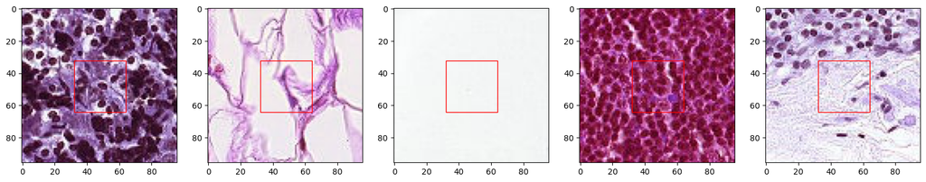

```python
# sample images WITHOUT cancer cells present in the center 32x32 region
show_img(train[train['label'] == 0].sample(5), True)
```

```
Showing image: 9ae717b9c1fef6de2f60bb473ed0a5a10bc248e7.tif with label: 1
Showing image: 52429e318db44ef2545bf69d32f3aba0b90d5f56.tif with label: 1
Showing image: 1762382cb5353004098a791dca4a5ef8ee4766a7.tif with label: 1
Showing image: c40e6202aff48eb1a731ea66ecbaaa08e315f8e7.tif with label: 1
Showing image: d03085c9100718f1637295edbd30ab5181c17dda.tif with label: 1
```

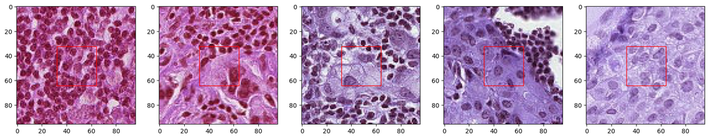

```python
# sample images WITH cancer cells present in the center 32x32 region
show_img(train[train['label'] == 1].sample(5), True)
```

### Check image sizes and identify any poor-quality images

```python
start_time = time.time()

bad_sizes = pd.DataFrame() # holds training records with images of size other than (96, 96, 3)
bad_quality = pd.DataFrame() # holds training records with images that have a small range (<100) of pixel values which are probably washed out, incorrectly taken, etc.

for i, img_n in enumerate(train['id']):
    img_path = '/kaggle/input/histopathologic-cancer-detection/train/' + img_n + '.tif'
    img_array = cv2.imread(img_path)

    # check sizes
    if img_array.shape != (96, 96, 3):
        bad_sizes = pd.concat([bad_sizes, train.iloc[[i]]])

    # check quality
    if np.max(img_array) - np.min(img_array) < 100:
        bad_quality = pd.concat([bad_quality, train.iloc[[i]]])

print("# of images with bad size:" + str(bad_sizes.shape[0]))
print("# of images with bad quality:" + str(bad_quality.shape[0]))

duration = time.time() - start_time
print("Time taken:" + str(round(duration, 2)) + " seconds")
```

```
# of images with bad size:0
# of images with bad quality:130
Time taken:376.12 seconds
```

Here I'm checking to see if there's any images not of size (96, 96, 3), or are poor quality. Images that have a small range of pixel values (I picked 100 above) probably had some issue and don't contain much information.

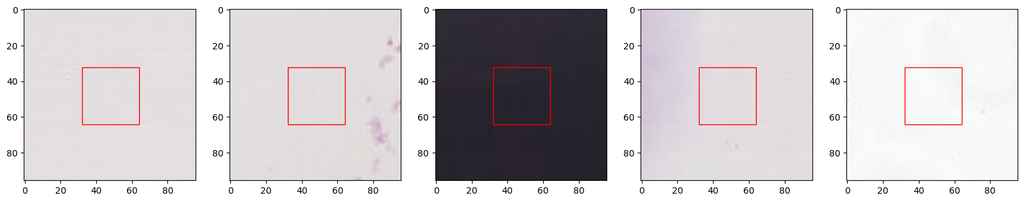

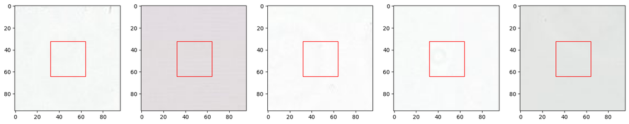

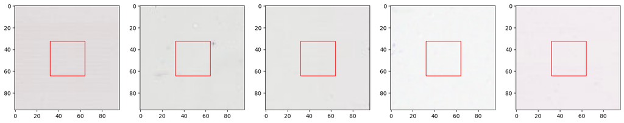

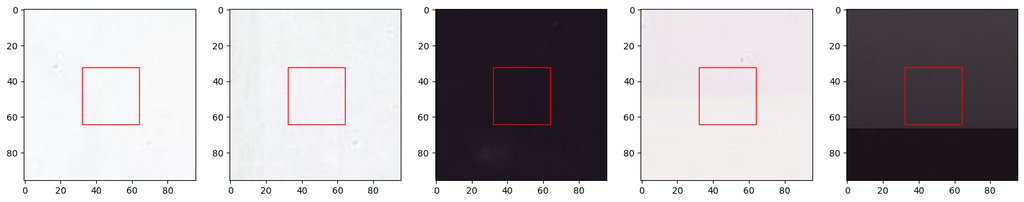

```python
for i in range(0, min(20, bad_quality.shape[0]), 5):
    show_img(bad_quality[i:i+5])
```

```python
train = train.drop(bad_quality.index, axis = 0)
train.shape
```

```
(39870, 2)
```

# Data Preparation

### Normalizing the training data

It will be easier for the network to recognize patterns in the images if the pixel values are normalized. Here I'm centering all values around zero by subtracting the mean for each image array, and using those to build the training data the model will use.

```python
train_data = np.zeros(shape = (train.shape[0], 96, 96, 3))

for i, img_n in enumerate(train['id']):
    img_path = '/kaggle/input/histopathologic-cancer-detection/train/' + img_n + '.tif'
    img_array = cv2.imread(img_path)

    train_data[i] = img_array - img_array.mean()

train_labels = train['label']

print(train_data.shape)
print(train_labels.shape)
```

```
(39870, 96, 96, 3)
(39870,)
```

# Model Building

I experimented with a few different basic model architectures, details of which I explain a few cells down in the Model Architectures & Hyperparameter Tuning section.

I'll utilize dropout before the output layer to regularize and help the model generalize better. The optimizer used will be Adam with default parameters. Loss function will be binary cross-entropy which makes the most sense for binary classification problem. I'll also be evaluating using metrics accuracy and AUC.

```python
num_filters = 4
filter_size = (5, 5)
pool_size = (4, 4)
pool_stride = 4
dropout_p = 0.5

model = Sequential()
model.add(Conv2D(num_filters, filter_size, activation = 'relu'))
model.add(Conv2D(num_filters, filter_size, activation = 'relu'))
model.add(Conv2D(num_filters, filter_size, activation = 'relu'))
model.add(Conv2D(num_filters, filter_size, activation = 'relu'))
#model.add(BatchNormalization())
model.add(MaxPooling2D(pool_size = pool_size, strides = pool_stride))
model.add(Dropout(rate = dropout_p))
model.add(Flatten())
model.add(Dense(1, activation = 'sigmoid'))

model.compile('adam', loss = 'binary_crossentropy', metrics = ['accuracy', 'auc'])
```

```
I0000 00:00:1746949104.214953      19 gpu_device.cc:2022] Created device /job:localhost/replica:0/task:0/device:GPU:0 with 13942 MB memory:  -> device: 0, name: Tesla T4, pci bus id: 0000:00:04.0, compute capability: 7.5
I0000 00:00:1746949104.215667      19 gpu_device.cc:2022] Created device /job:localhost/replica:0/task:0/device:GPU:1 with 13942 MB memory:  -> device: 1, name: Tesla T4, pci bus id: 0000:00:05.0, compute capability: 7.5
```

# Model Training

When fitting the model, I'm using callbacks EarlyStopping and ReduceLROnPlateau.

- As the name suggests, EarlyStopping interrupts training once it sees a metric (by default validation loss) get worse for a number of epochs. By setting patience = 5, I'm letting it know to do the interruption after 5 consecutive epochs with increasing validation loss. Then, the restore_best_weights = True parameter resets the weights back to the last 'best' performing epoch.
- ReduceLROnPlateau diminishes the learning rate as the validation loss stagnates. However, in my experience I didn't see this ever kick in before EarlyStopping did so I didn't reap much benefit from it.

```python
es = EarlyStopping(verbose = 1, patience = 5, restore_best_weights = True)
rl = ReduceLROnPlateau(verbose = 1)

results = model.fit(x = train_data, y = train_labels, epochs = 20, validation_split = 0.1, callbacks = [es, rl])
```

[output not shown]

```
  24/1122 ━━━━━━━━━━━━━━━━━━━━ 7s 7ms/step - accuracy: 0.5814 - auc: 0.5517 - loss: 10.0052
```

```
I0000 00:00:1746949122.411843      64 device_compiler.h:188] Compiled cluster using XLA!  This line is logged at most once for the lifetime of the process.
```

```
1122/1122 ━━━━━━━━━━━━━━━━━━━━ 20s 12ms/step - accuracy: 0.6053 - auc: 0.6185 - loss: 1.4075 - val_accuracy: 0.7356 - val_auc: 0.8151 - val_loss: 0.5624 - learning_rate: 0.0010
1122/1122 ━━━━━━━━━━━━━━━━━━━━ 8s 7ms/step - accuracy: 0.7612 - auc: 0.8247 - loss: 0.5295 - val_accuracy: 0.7863 - val_auc: 0.8484 - val_loss: 0.4896 - learning_rate: 0.0010
1122/1122 ━━━━━━━━━━━━━━━━━━━━ 8s 7ms/step - accuracy: 0.7754 - auc: 0.8409 - loss: 0.4983 - val_accuracy: 0.7908 - val_auc: 0.8573 - val_loss: 0.4670 - learning_rate: 0.0010
1122/1122 ━━━━━━━━━━━━━━━━━━━━ 8s 7ms/step - accuracy: 0.7855 - auc: 0.8540 - loss: 0.4750 - val_accuracy: 0.7951 - val_auc: 0.8615 - val_loss: 0.4623 - learning_rate: 0.0010
1122/1122 ━━━━━━━━━━━━━━━━━━━━ 8s 7ms/step - accuracy: 0.7879 - auc: 0.8560 - loss: 0.4690 - val_accuracy: 0.7710 - val_auc: 0.8651 - val_loss: 0.4828 - learning_rate: 0.0010
1122/1122 ━━━━━━━━━━━━━━━━━━━━ 8s 7ms/step - accuracy: 0.7985 - auc: 0.8673 - loss: 0.4518 - val_accuracy: 0.8071 - val_auc: 0.8762 - val_loss: 0.4433 - learning_rate: 0.0010
1122/1122 ━━━━━━━━━━━━━━━━━━━━ 8s 7ms/step - accuracy: 0.8042 - auc: 0.8778 - loss: 0.4353 - val_accuracy: 0.7963 - val_auc: 0.8871 - val_loss: 0.4452 - learning_rate: 0.0010
1122/1122 ━━━━━━━━━━━━━━━━━━━━ 8s 8ms/step - accuracy: 0.8097 - auc: 0.8782 - loss: 0.4337 - val_accuracy: 0.8076 - val_auc: 0.8844 - val_loss: 0.4258 - learning_rate: 0.0010
1122/1122 ━━━━━━━━━━━━━━━━━━━━ 8s 8ms/step - accuracy: 0.8163 - auc: 0.8903 - loss: 0.4136 - val_accuracy: 0.8069 - val_auc: 0.8884 - val_loss: 0.4230 - learning_rate: 0.0010
1122/1122 ━━━━━━━━━━━━━━━━━━━━ 8s 8ms/step - accuracy: 0.8149 - auc: 0.8898 - loss: 0.4144 - val_accuracy: 0.8194 - val_auc: 0.8940 - val_loss: 0.4039 - learning_rate: 0.0010
1122/1122 ━━━━━━━━━━━━━━━━━━━━ 8s 8ms/step - accuracy: 0.8240 - auc: 0.8991 - loss: 0.3974 - val_accuracy: 0.8222 - val_auc: 0.8919 - val_loss: 0.4094 - learning_rate: 0.0010
1122/1122 ━━━━━━━━━━━━━━━━━━━━ 9s 8ms/step - accuracy: 0.8252 - auc: 0.8982 - loss: 0.3987 - val_accuracy: 0.8294 - val_auc: 0.9007 - val_loss: 0.3890 - learning_rate: 0.0010
1122/1122 ━━━━━━━━━━━━━━━━━━━━ 9s 8ms/step - accuracy: 0.8240 - auc: 0.8991 - loss: 0.3962 - val_accuracy: 0.8320 - val_auc: 0.9000 - val_loss: 0.3925 - learning_rate: 0.0010
1122/1122 ━━━━━━━━━━━━━━━━━━━━ 9s 8ms/step - accuracy: 0.8278 - auc: 0.9040 - loss: 0.3871 - val_accuracy: 0.8151 - val_auc: 0.9004 - val_loss: 0.4178 - learning_rate: 0.0010
1122/1122 ━━━━━━━━━━━━━━━━━━━━ 9s 8ms/step - accuracy: 0.8322 - auc: 0.9057 - loss: 0.3830 - val_accuracy: 0.8277 - val_auc: 0.8994 - val_loss: 0.3940 - learning_rate: 0.0010
1122/1122 ━━━━━━━━━━━━━━━━━━━━ 9s 8ms/step - accuracy: 0.8290 - auc: 0.9049 - loss: 0.3853 - val_accuracy: 0.8292 - val_auc: 0.9040 - val_loss: 0.3861 - learning_rate: 0.0010
1122/1122 ━━━━━━━━━━━━━━━━━━━━ 9s 8ms/step - accuracy: 0.8303 - auc: 0.9037 - loss: 0.3861 - val_accuracy: 0.8274 - val_auc: 0.9029 - val_loss: 0.3871 - learning_rate: 0.0010
1122/1122 ━━━━━━━━━━━━━━━━━━━━ 9s 8ms/step - accuracy: 0.8294 - auc: 0.9050 - loss: 0.3843 - val_accuracy: 0.8297 - val_auc: 0.9046 - val_loss: 0.3812 - learning_rate: 0.0010
1122/1122 ━━━━━━━━━━━━━━━━━━━━ 9s 8ms/step - accuracy: 0.8350 - auc: 0.9085 - loss: 0.3772 - val_accuracy: 0.8327 - val_auc: 0.9009 - val_loss: 0.3922 - learning_rate: 0.0010
1122/1122 ━━━━━━━━━━━━━━━━━━━━ 9s 8ms/step - accuracy: 0.8316 - auc: 0.9059 - loss: 0.3829 - val_accuracy: 0.8116 - val_auc: 0.8954 - val_loss: 0.4155 - learning_rate: 0.0010
Restoring model weights from the end of the best epoch: 18.
```

```python
# Display training and validation accuracies by epoch so it's easier to read
pd.DataFrame({'Epoch': np.arange(1,len(results.history['accuracy'])+1),
              'Training Accuracy': results.history['accuracy'],
              'Validation Accuracy': results.history['val_accuracy']})
```

|  | Epoch | Training Accuracy | Validation Accuracy |
| --- | --- | --- | --- |
| 0 | 1 | 0.666137 | 0.735641 |
| 1 | 2 | 0.765348 | 0.786305 |
| 2 | 3 | 0.776579 | 0.790820 |
| 3 | 4 | 0.786751 | 0.795084 |
| 4 | 5 | 0.792659 | 0.771006 |
| 5 | 6 | 0.797759 | 0.807123 |
| 6 | 7 | 0.801745 | 0.796338 |
| 7 | 8 | 0.810244 | 0.807625 |
| 8 | 9 | 0.814174 | 0.806872 |
| 9 | 10 | 0.817490 | 0.819413 |
| 10 | 11 | 0.823454 | 0.822172 |
| 11 | 12 | 0.823900 | 0.829446 |
| 12 | 13 | 0.823120 | 0.831954 |
| 13 | 14 | 0.826603 | 0.815149 |
| 14 | 15 | 0.829585 | 0.827690 |
| 15 | 16 | 0.828665 | 0.829195 |
| 16 | 17 | 0.828944 | 0.827439 |
| 17 | 18 | 0.830449 | 0.829697 |
| 18 | 19 | 0.831982 | 0.832706 |
| 19 | 20 | 0.830839 | 0.811638 |

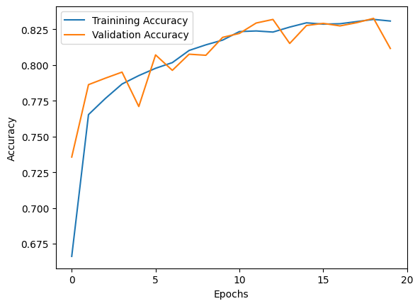

```python
# Plot training and validation accuracies by epoch
plt.plot(results.history['accuracy'], label = 'Trainining Accuracy')
plt.plot(results.history['val_accuracy'], label = 'Validation Accuracy')
plt.xlabel('Epochs')
plt.ylabel('Accuracy')
plt.legend()
plt.xticks(ticks = [0, 5, 10, 15, 20])
plt.show()
```

# Experimenting with Model Architectures

I experimented with different model architectures, # layers, # filters, etc. and compared the resulting training and validation accuracies under each.

Below is a table of the results I collected from changing model architecture. I tried changing the number of convolution layers used (2-4), and testing the usage of a Batch Normalization layer, and Dropout (25%, 50%). I tried all combinations and chose the one with the best validation accuracy.

| ConvLayers | BatchNormalization Layer | Dropout Used | Dropout % | Training Accuracy | Validation Accuracy |
| --- | --- | --- | --- | --- | --- |
| 2 | No | No | - | 81.5% | 63.7% |
| 3 | No | No | - | 69.9% | 62.1% |
| 4 | No | No | - | 82.5% | 68.3% |
| 2 | Yes | No | - | 82.8% | 63.1% |
| 3 | Yes | No | - | 75.2% | 68.5% |
| 4 | Yes | No | - | 79.5% | 66.5% |
| 2 | No | Yes | 25% | 63.0% | 55.9% |
| 3 | No | Yes | 25% | 58.2% | 57.1% |
| 4 | No | Yes | 25% | 67.0% | 65.3% |
| 2 | No | Yes | 50% | 58.8% | 60.3% |
| 3 | No | Yes | 50% | 75.9% | 76.0% |
| 4 | No | Yes | 50% | 79.4% | **76.4%*** |
| 2 | Yes | Yes | 25% | 79.1% | 69.9% |
| 3 | Yes | Yes | 25% | 76.3% | 64.5% |
| 4 | Yes | Yes | 25% | 77.6% | 68.3% |
| 2 | Yes | Yes | 50% | 81.2% | 72.1% |
| 3 | Yes | Yes | 50% | 80.7% | 73.7% |
| 4 | Yes | Yes | 50% | 82.8% | 72.9% |

# Hyperparameter Tuning

Here I mainly experimented with changing # filters, filter size, pool size, and pool stride, using the final architecture I settled on from above. I realized part-way through that I need to test all combinations of these along with different model architectures, but for time's sake I limited it to just these parameters for now and leaving this for follow-up when I have more time.

| # of filters | filter size | pool_size | pool_stride | Training Accuracy | Validation Accuracy |
| --- | --- | --- | --- | --- | --- |
| 1 | 3x3 | 2x2 | 2 | 62.1% | 60.7% |
| 2 | 3x3 | 2x2 | 2 | 67.5% | 66.3% |
| 3 | 3x3 | 2x2 | 2 | 74.3% | 70.5% |
| 4 | 3x3 | 2x2 | 2 | 62.2% | 61.3% |
| 1 | 5x5 | 2x2 | 2 | 60.6% | 60.3% |
| 2 | 5x5 | 2x2 | 2 | 69.6% | 65.9% |
| 3 | 5x5 | 2x2 | 2 | 74.5% | 70.3% |
| 4 | 5x5 | 2x2 | 2 | 79.7% | 70.5% |
| 1 | 3x3 | 4x4 | 4 | 60.6% | 60.1% |
| 2 | 3x3 | 4x4 | 4 | 75.1% | 77.8% |
| 3 | 3x3 | 4x4 | 4 | 72.2% | 70.7% |
| 4 | 3x3 | 4x4 | 4 | 76.1% | 71.5% |
| 1 | 5x5 | 4x4 | 4 | 60.1% | 60.3% |
| 2 | 5x5 | 4x4 | 4 | 76.0% | **79.0%*** |
| 3 | 5x5 | 4x4 | 4 | 72.8% | 72.3% |
| 4 | 5x5 | 4x4 | 4 | 76.3% | 77.4% |

### General findings from hyperparameter tuning

- Using only 1 filter led to mcuh lower training & validation accuracy than using any higher number of filters.
- Using more filters typically led to higher training accuracy, but not always higher validation accuracy which was a sign of overfitting. The 'sweet spot' from my tests looked to be 2 or 3 filters.
- The highest validation accuracy was achieved by using 2 5x5 filters, and 4x4 pooling size. A very close second was using 2 3x3 filters with 4x4 pooling size.
- Using a larger pooling size generally led to a higher validation accuracy across the board.

# Final Model Performance

```
1246/1246 ━━━━━━━━━━━━━━━━━━━━ 4s 3ms/step
```

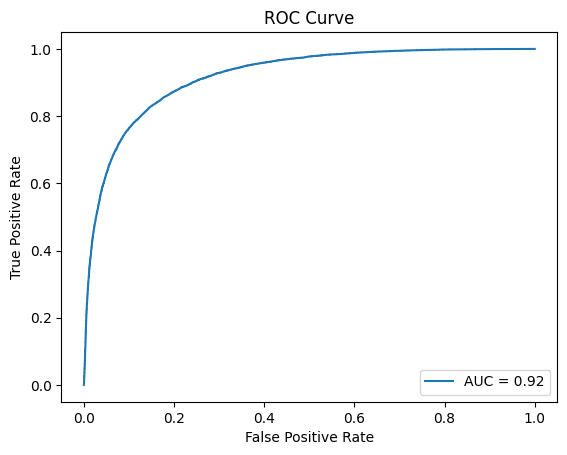

```python
pred_proba = model.predict(x = train_data).reshape(-1)
actual = train_labels

fpr, tpr, thresholds = roc_curve(actual, pred_proba)
auc_score = auc(fpr, tpr)

plt.plot(fpr, tpr, label = 'AUC = ' + str(round(auc_score, 2)))
plt.xlabel('False Positive Rate')
plt.ylabel('True Positive Rate')
plt.title('ROC Curve')
plt.legend(loc = 'lower right')
plt.show()
```

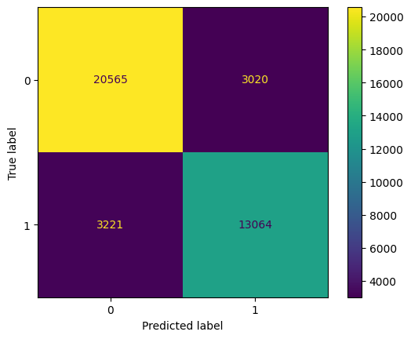

```python
pred = (pred_proba >= 0.5).astype(int)
cm = confusion_matrix(actual, pred)

ConfusionMatrixDisplay(cm).plot()
plt.show()
```

```python
tn = cm[0,0]
fp = cm[0,1]
fn = cm[1,0]
tp = cm[1,1]

print("Accuracy: ", (tn+tp)/(tn+fp+fn+tp))
print("Precision: ", tp/(tp+fp))
print("Recall: ", tp/(tp+fn))
```

```
Accuracy:  0.8434662653624279
Precision:  0.8122357622481969
Recall:  0.8022106232729506
```

# Generate Test Predictions

```python
test = glob(os.path.join('/kaggle/input/histopathologic-cancer-detection/test/', '*.tif'))
test_data = np.zeros(shape = (len(test), 96, 96, 3))
test_names = []

for i, file in enumerate(test):
    img_name = file.split("/")[5].split(".tif")[0]
    img_array = cv2.imread('/kaggle/input/histopathologic-cancer-detection/test/' + img_name + ".tif")

    # normalize and add to test set
    test_data[i] = img_array - img_array.mean()
    test_names.append(img_name)

print(test_data.shape)
```

```
(57458, 96, 96, 3)
```

```python
# Building test predictions array in parts to avoid kernel memory exceeded error
test_data_split = np.array_split(test_data, 10)
test_proba = []

for i, t in enumerate(test_data_split):
    test_proba.extend(model.predict(x = t).reshape(-1))

len(test_proba)
```

```
180/180 ━━━━━━━━━━━━━━━━━━━━ 1s 5ms/step
180/180 ━━━━━━━━━━━━━━━━━━━━ 0s 2ms/step
180/180 ━━━━━━━━━━━━━━━━━━━━ 0s 2ms/step
180/180 ━━━━━━━━━━━━━━━━━━━━ 0s 3ms/step
180/180 ━━━━━━━━━━━━━━━━━━━━ 0s 2ms/step
180/180 ━━━━━━━━━━━━━━━━━━━━ 0s 2ms/step
180/180 ━━━━━━━━━━━━━━━━━━━━ 0s 3ms/step
180/180 ━━━━━━━━━━━━━━━━━━━━ 0s 2ms/step
180/180 ━━━━━━━━━━━━━━━━━━━━ 1s 5ms/step
180/180 ━━━━━━━━━━━━━━━━━━━━ 0s 2ms/step
```

```
57458
```

```python
submission = pd.DataFrame({'id': test_names, 'label': test_proba})

submission.head()
```

|  | id | label |
| --- | --- | --- |
| 0 | a7ea26360815d8492433b14cd8318607bcf99d9e | 0.537521 |
| 1 | 59d21133c845dff1ebc7a0c7cf40c145ea9e9664 | 0.159432 |
| 2 | 5fde41ce8c6048a5c2f38eca12d6528fa312cdbb | 0.255853 |
| 3 | bd953a3b1db1f7041ee95ff482594c4f46c73ed0 | 0.744271 |
| 4 | 523fc2efd7aba53e597ab0f69cc2cbded7a6ce62 | 0.373081 |

```python
submission.to_csv('submission.csv', index = False, header = True)
```

# Conclusions and Next Steps

Although I was only able to use a subset of training images out of the whole sample, the model achieved ~80% training and validation accuracies, as well as an AUC over 0.9. Including more training images would very likely have helped improve the metrics, but I felt limited by the fact that the Kaggle kernel kept timing out if I used more images. I couldn't easily tell what the issue was from the logs, so I may need to see what others did on their notebooks to get around this issue, or utilize different methods/libraries.

I believe accuracy could also be improved more by employing a more complex model architecture, but since I am not an expert at this yet yet I would probably want to try a pre-built model such as ResNet or Inception Net first. These are models that have already proven themselves by performing well in the ImageNet image classification competition.